# ggplot

## Annotations

- Labels: xlab(), ylab(), ggtitle()
- Two standard themes
  - theme_gray() - default
  - theme_bw()

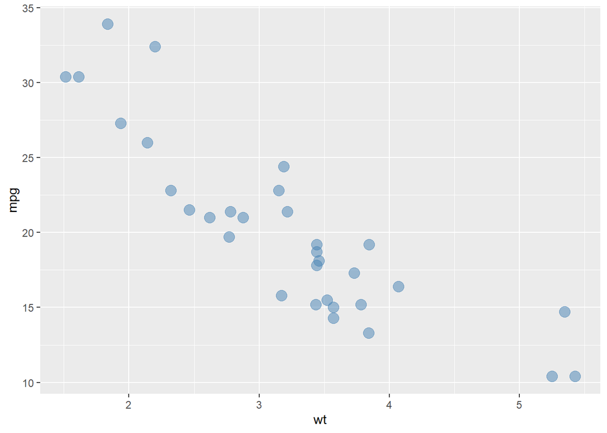

```r
plot + geom_point(size = 4,color = "steelblue", alpha = 0.5)
```

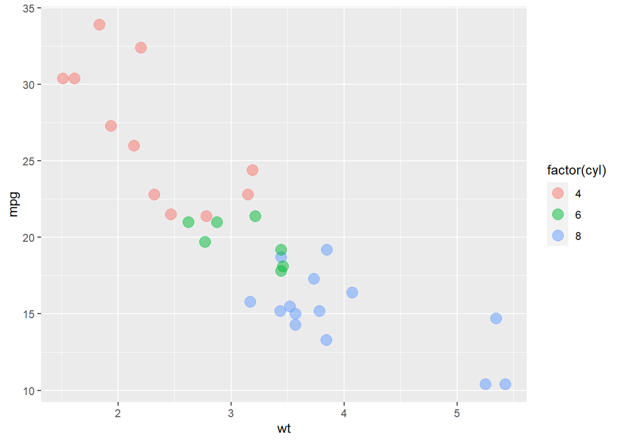

```r
plot + geom_point(aes(color = factor(cyl)),size = 4, alpha = 0.5)
```

Custom colors

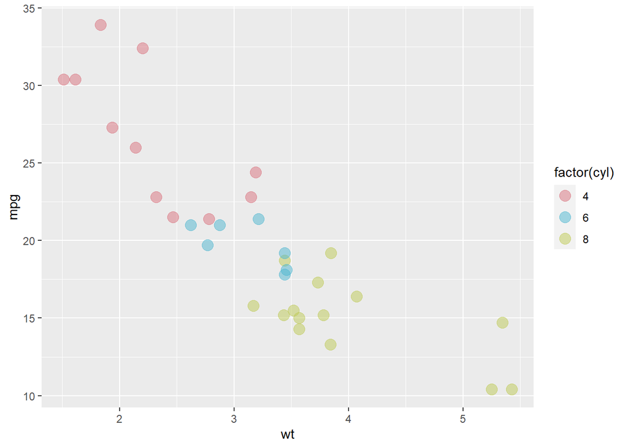

```r
colors <- c("4" = "#D9717D", "6" = "#4DB6D0", "8" = "#BECA55")
plot + geom_point(aes(color = factor(cyl)),size = 4, alpha = 0.5) + scale_color_manual(values = colors)
```

Adding labels

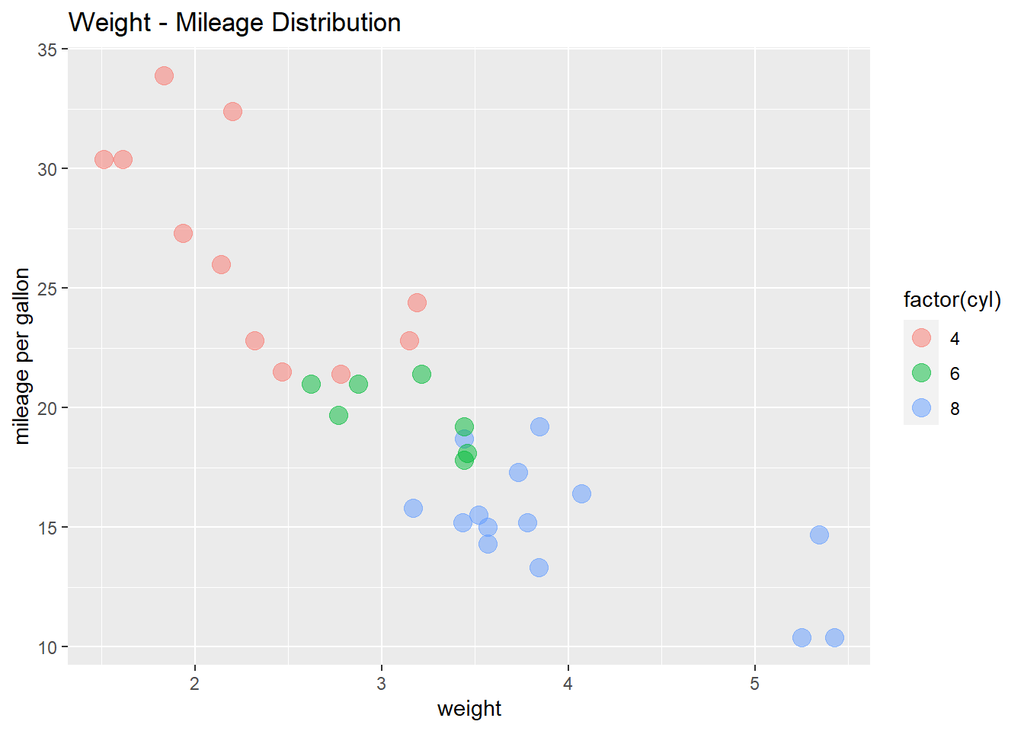

```r
plot + geom_point(aes(color = factor(cyl)),size = 4, alpha = 0.5) + labs(title = "Weight - Mileage Distribution", x = "weight", y = "mileage per gallon")
```

## Dealing with scaling and cartesian coordinates

To create a line plot to analyse outlier within data

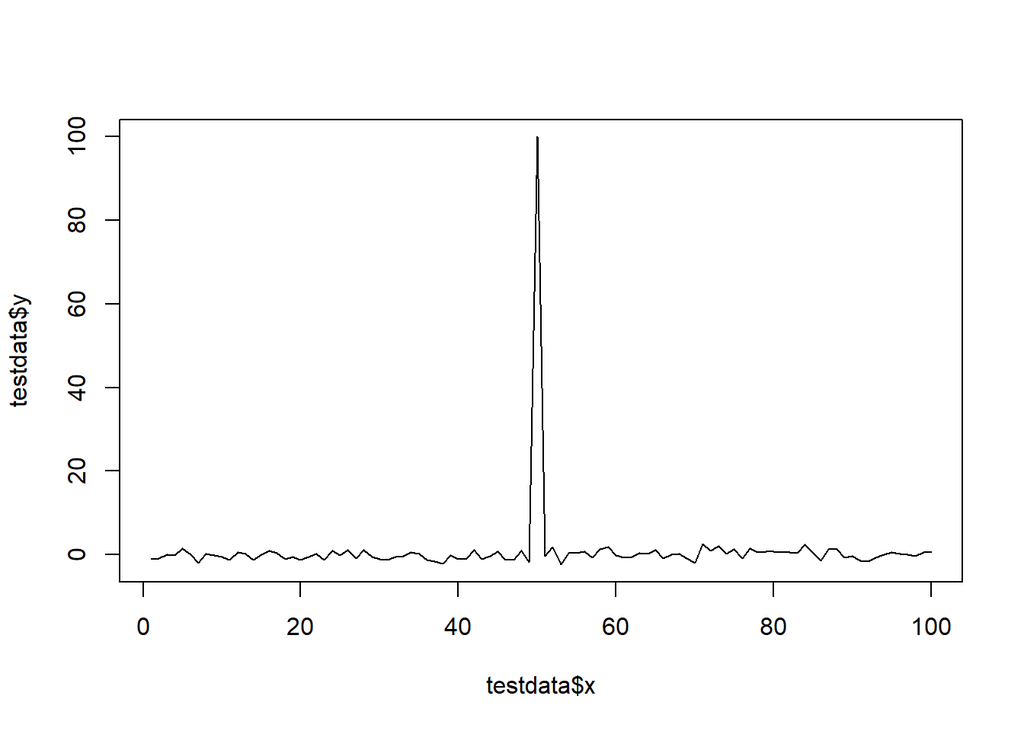

```r
testdata = data.frame(x = 1:100, y = rnorm(100))
testdata[50,2] = 100
plot(testdata$x,testdata$y, type = "l")
```

To only look at the regular data using the base plot function

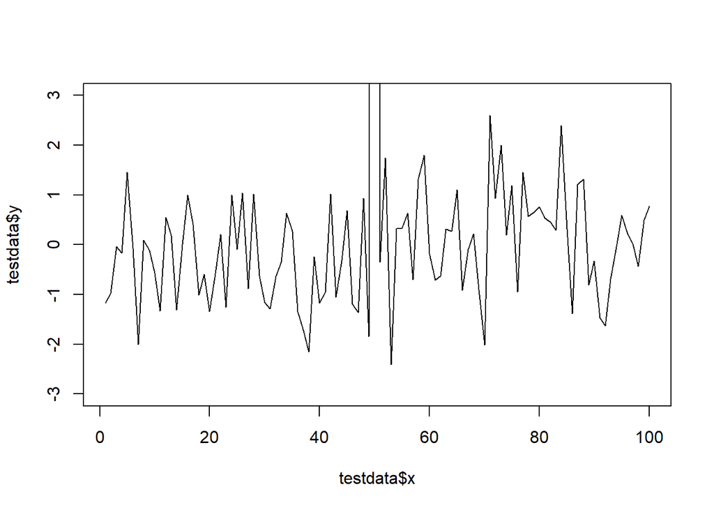

```r
plot(testdata$x,testdata$y, type = "l", ylim = c(-3,3))
```

In case of ggplot adding the ylim() function to the plot first subsets the data to only include points within limit and then plot the data

- The original data:

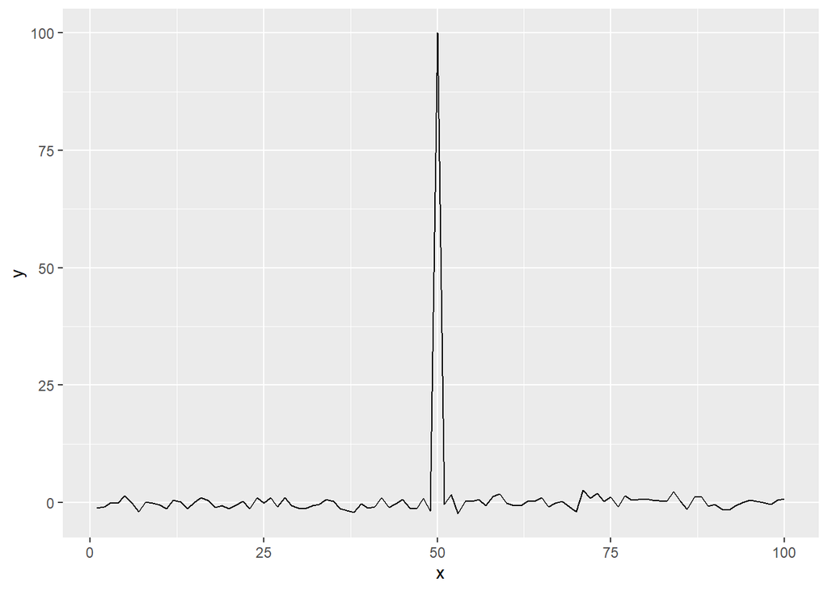

```r
testplot = ggplot(
  testdata,
  aes(x = x,
      y = y)
)
testplot + geom_line()
```

- adding ylim()

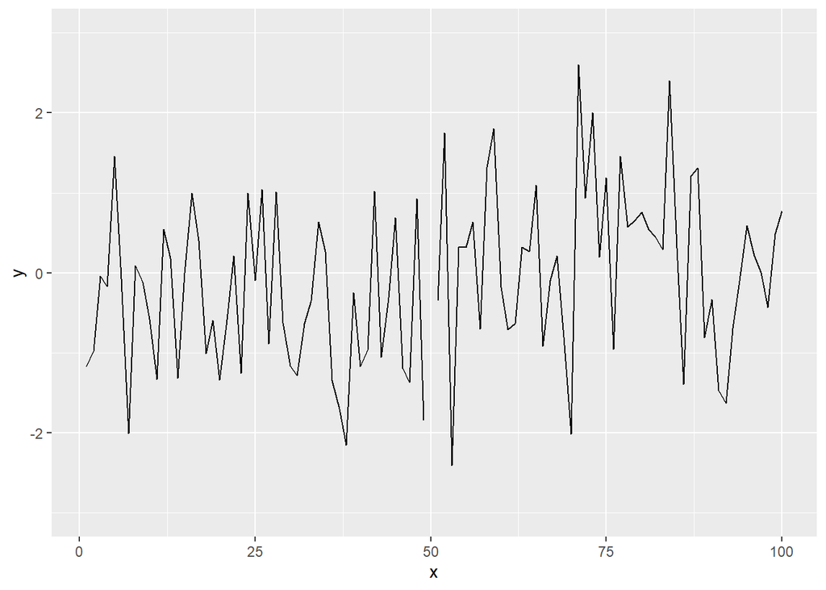

```r
testplot + geom_line() + ylim(-3,3)
```

We can clearly see the data at x = 50 is missing, to solve this we add coord_cartesian() instead of ylim() directly

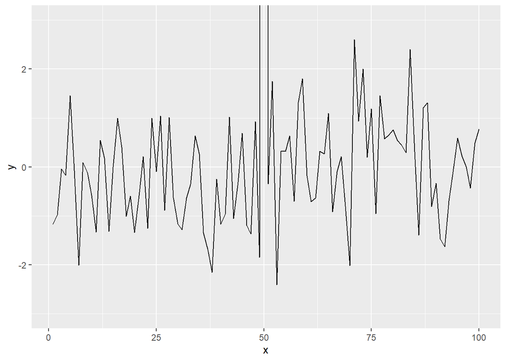

```r
testplot + geom_line() + coord_cartesian(ylim = c(-3,3))
```

## Dealing with continous variables during plot

In mnay cases we’d be required to plot by conditioning continous variables, there are several ways to go about this, one method is to categorise the varaible into reasonable series of ranges, we use the cut() function for this purpose

```r
data_weather = nycflights13::weather
data_weather$month = factor(data_weather$month)
cutpoints_1 = quantile(data_weather$humid, seq(0,1,length = 4), na.rm = T)
cutpoints_2 = quantile(data_weather$day, seq(0,1,length = 3), na.rm = T)
data_weather$humid_levels = cut(data_weather$humid, cutpoints_1)
data_weather$hour_levels = cut(data_weather$hour, cutpoints_2)
levels(data_weather$humid_levels)
```

```
## [1] "(12.7,51.8]" "(51.8,72.5]" "(72.5,100]"
```

```r
levels(data_weather$hour_levels)
```

```
## [1] "(1,16]"  "(16,31]"
```

Cleaning up the variable

```r
lev_humid = levels(data_weather$humid_levels)
lev_hour = levels(data_weather$hour_levels)
data_weather$humid_levels = factor(data_weather$humid_levels, levels = lev_humid, labels = c("low","med","high"))
data_weather$hour_levels = factor(data_weather$hour_levels, levels = lev_hour, labels = c("day","night"))
levels(data_weather$humid_levels)
```

```
## [1] "low"  "med"  "high"
```

```r
levels(data_weather$hour_levels)
```

```
## [1] "day"   "night"
```

Plotting the data

[figure not shown]

```r
ggplot(
  data_weather[complete.cases(data_weather[-11]),],
  aes(
    x = temp,
    y = dewp
  )
) + geom_point(
  alpha = 0.5
) + facet_wrap(
  hour_levels~humid_levels,
  nrow = 2,
  ncol = 3
) + geom_smooth(
  method = "lm",
  se = F,
  col = "steelblue"
) + labs(
  title = "Weight - Mileage Distribution",
  x = "Weight",
  y = "Mileage"
)
```